# Exploratory Data Analysis in R

joseangeldiazg

November 25 2017

# Ejemplo 1, hip dataset

Descargate el dataset hip con el siguiente commando

```r
hip  <-read.table("http://astrostatistics.psu.edu/datasets/HIP_star.dat", header=T,fill=T)
```

- Una vez descargado comprueba la dimensión y los nombres de las columnas del dataset. ¿Qué dimensión tiene? ¿qué datos alberga?

```r
str(hip)
```

```
## 'data.frame':    2719 obs. of  9 variables:
##  $ HIP  : int  2 38 47 54 74 81 110 135 143 149 ...
##  $ Vmag : num  9.27 8.65 10.78 10.57 9.93 ...
##  $ RA   : num  0.0038 0.111 0.1352 0.1517 0.2219 ...
##  $ DE   : num  -19.5 -79.1 -56.8 18 35.8 ...
##  $ Plx  : num  21.9 23.8 24.4 21 24.2 ...
##  $ pmRA : num  181.2 162.3 -44.2 367.1 157.7 ...
##  $ pmDE : num  -0.93 -62.4 -145.9 -19.49 -40.31 ...
##  $ e_Plx: num  3.1 0.78 1.97 1.71 1.36 1.28 1.91 1.22 1.64 2.17 ...
##  $ B.V  : num  0.999 0.778 1.15 1.03 1.068 ...
```

Con el comando **str** vemos la información solicitada concretamente 2719 observaciones con 9 características, además vemos el tipo de dato de cada característica.

- Muestra por pantalla la columna de la variable RA

```r
hip[,3]
```

```
##    [1]   0.003797   0.111047   0.135192   0.151656   0.221873   0.243864
##    [7]   0.348708   0.426746   0.455182   0.478685   0.612287   0.696411
##   [13]   0.972063   1.099309   1.102623   1.244275   1.281668   1.369764
##   [19]   1.423333   1.468617   1.843365   1.966150   2.261459   2.315143
##   [25]   2.352249   2.431558   2.768701   2.878592   2.898287   2.906145
##   [31]   3.125492   3.136756   3.287636   3.470117   3.499989   3.517613
##   [37]   3.542473   3.561294   3.584257   3.588865   3.768990   4.047722
##   [43]   4.101227   4.179702   4.342874   4.375348   4.376308   4.386210
##   [49]   4.387165   4.401851   4.457699   4.582106   4.608357   4.901928
##   [55]   5.280108   5.398303   5.604551   5.644953   5.735995   5.750338
##   [61]   5.770342   5.907064   5.913140   5.947756   6.036948   6.091006
##   [67]   6.256391   6.266819   6.285408   6.667964   6.930394   6.957396
##   [73]   7.292119   7.368555   7.427643   7.465869   7.575263   7.608228
##   [79]   7.689831   7.801700   7.885670   8.033768   8.182476   8.613389
##   [85]   8.622360   8.712882   8.739422   8.807178   8.908298   8.967503
```

[output cut: 153 more lines]

- Calcula las tendencias centrales de todos los datos del dataset (mean, media) utilizando la function apply

```r
apply(hip,2,mean, na.rm=T)
```

```
##           HIP          Vmag            RA            DE           Plx
## 56549.4828981     8.2593858   173.4529975    -0.1397663    22.1980213
##          pmRA          pmDE         e_Plx           B.V
##     5.3761346   -63.9419934     1.6267929     0.7615299
```

```r
apply(hip,2,median, na.rm=T)
```

```
##          HIP         Vmag           RA           DE          Plx
## 56413.000000     8.280000   173.369788     3.254234    22.100000
##         pmRA         pmDE        e_Plx          B.V
##    10.550000   -49.480000     1.140000     0.710500
```

- Haz lo mismo para las medidas de dispersión mínimo y máximo.

```r
apply(hip,2,min, na.rm=T)
```

```
##          HIP         Vmag           RA           DE          Plx
##     2.000000     0.450000     0.003797   -87.202730    20.000000
##         pmRA         pmDE        e_Plx          B.V
##  -868.010000 -1392.300000     0.450000    -0.158000
```

```r
apply(hip,2,max, na.rm=T)
```

```
##          HIP         Vmag           RA           DE          Plx
## 120003.00000     12.74000    359.95468     88.30268     25.00000
##         pmRA         pmDE        e_Plx          B.V
##    781.34000    481.19000     46.91000      2.80000
```

- ¿Sería posible hacerlo con un único comando? ¿Que hace la función range()

Si que sería posible, para ello usaremos la función range que nos da el rango de valores comprendido para una determinada característica del dataset.

```r
apply(hip,2,range, na.rm=T)
```

```
##         HIP  Vmag         RA        DE Plx    pmRA     pmDE e_Plx    B.V
## [1,]      2  0.45   0.003797 -87.20273  20 -868.01 -1392.30  0.45 -0.158
## [2,] 120003 12.74 359.954685  88.30268  25  781.34   481.19 46.91  2.800
```

- Sin embargo las medidas más populares de dispersión son la varianza (var()), su desviación standard (sd()) y la desviación absoluta de la mediana o MAD. Calcula estas medidas para los valores de RA.

```r
apply(hip,2,var, na.rm=T)
```

```
##          HIP         Vmag           RA           DE          Plx
## 1.266456e+09 3.552207e+00 1.156632e+04 1.515575e+03 2.008437e+00
##         pmRA         pmDE        e_Plx          B.V
## 2.591451e+04 1.985011e+04 4.896779e+00 1.012434e-01
```

```r
apply(hip,2,sd, na.rm=T)
```

```
##          HIP         Vmag           RA           DE          Plx
## 3.558731e+04 1.884730e+00 1.075468e+02 3.893039e+01 1.417193e+00
##         pmRA         pmDE        e_Plx          B.V
## 1.609799e+02 1.408904e+02 2.212867e+00 3.181876e-01
```

```r
apply(hip,2,mad, na.rm=T)
```

```
##          HIP         Vmag           RA           DE          Plx
## 4.909037e+04 1.882902e+00 1.469334e+02 4.398403e+01 1.764294e+00
##         pmRA         pmDE        e_Plx          B.V
## 1.416476e+02 9.949729e+01 4.892580e-01 2.809527e-01
```

- Imagina que quieres calcular dos de estos valores de una sola vez. ¿Te serviría este código?

```r
f = function(x) c(median(x), mad(x))
f(hip[,1])
```

```
## [1] 56413.00 49090.37
```

Si que valdría y calcularía para la columna 1 la mediana y la desviación absoluta de la mediana.

- ¿Cuál sería el resultado de aplicar apply(hip,2,f)?

El resultado de esta función sería aplicar para cada columna la mediana y la desviación absoluta de la mediana.

```r
apply(hip,2,f)
```

```
##           HIP     Vmag       RA        DE       Plx     pmRA      pmDE
## [1,] 56413.00 8.280000 173.3698  3.254234 22.100000  10.5500 -49.48000
## [2,] 49090.37 1.882902 146.9334 43.984032  1.764294 141.6476  99.49729
##         e_Plx B.V
## [1,] 1.140000  NA
## [2,] 0.489258  NA
```

Vamos a medir la dispersión de la muestra utilizando el concepto de cuartiles. El percentil 90 es aquel dato que excede en un 10% a todos los demás datos. El cuartil (quantile) es el mismo concento, solo que habla de proporciones en vez de porcentajes. De forma que el percentil 90 es lo mismo que el cuartil 0.90. La mediana “median” de un dataset es el valor más central, en otras palabras exactamente la mitad del dataset excede la mediana.

- Calcula el cuartil .10 y .50 para la columna RA del dataset hip. Sugerencia: quantile()

```r
quantile(hip$RA, probs = c(0.1, 0.5))
```

```
##       10%       50%
##  28.92324 173.36979
```

- Los cuantiles 0.25 y 0.75 se conocen como el first quartile y el third quartile, respectivamente. Calcula los cuatro cuartiles para RA con un único comando.

```r
quantile(hip$RA, probs=c(0.25,0.5,0.75))
```

```
##       25%       50%       75%
##  70.14137 173.36979 266.92332
```

- Otra medida de dispersión es la diferencia entre el primer y el tercer cuartil conocida como rango intercuartil (IQR) Inter Quantile Range. ¿Obtienes ese valor con la función summary()?

El valor como tal no es ofrecido por la función summary, pero si que obtenemos los valores necesarios para calcularlo. Si queremos tenerlo directamente debemos usar la funcion **IQR.**

```r
summary(hip$RA, na.rm=T)
```

```
##     Min.  1st Qu.   Median     Mean  3rd Qu.     Max.
##   0.0038  70.1414 173.3698 173.4530 266.9233 359.9547
```

```r
IQR(hip$RA)
```

```
## [1] 196.782
```

Hasta ahora has ignorado la presencia de valores perdidos NA. La función any() devuelve TRUE si se encuentra al menos un TRUE en el vector que damos como argumento. Su combinación con is.na es muy útil.

- ¿Qué obtienes cuando ejecutas el siguiente comando? ¿Cómo lo interpretas?

El siguiente comando, lo que hace es crear una función hasNA que nos dice si algun elemento de los datos que se le pasan como argumento es un *missing value*. Con la funcion apply, lo que hacemos es usarlo para cada columna del dataset hip y este nos devuelve que en la variable B.V, tenemos valores perdidos.

```r
hasNA = function(x) any(is.na(x))
apply(hip,2,hasNA)
```

```
##   HIP  Vmag    RA    DE   Plx  pmRA  pmDE e_Plx   B.V
## FALSE FALSE FALSE FALSE FALSE FALSE FALSE FALSE  TRUE
```

- Normalmente querríamos poder usar las funciones sobre el resto de datos que no son NA: Para ello podemos utilizar la función na.omit. ¿Que ocurre cuando lo hacemos?. Usando apply calcula la media para hip y hip1. Intenta calcular la media de forma que solo cambie la de B.V cuando ignores los valores NA.
- Obten una idea aproximada de tus datos mediante la creación de un boxplot del hip dataset

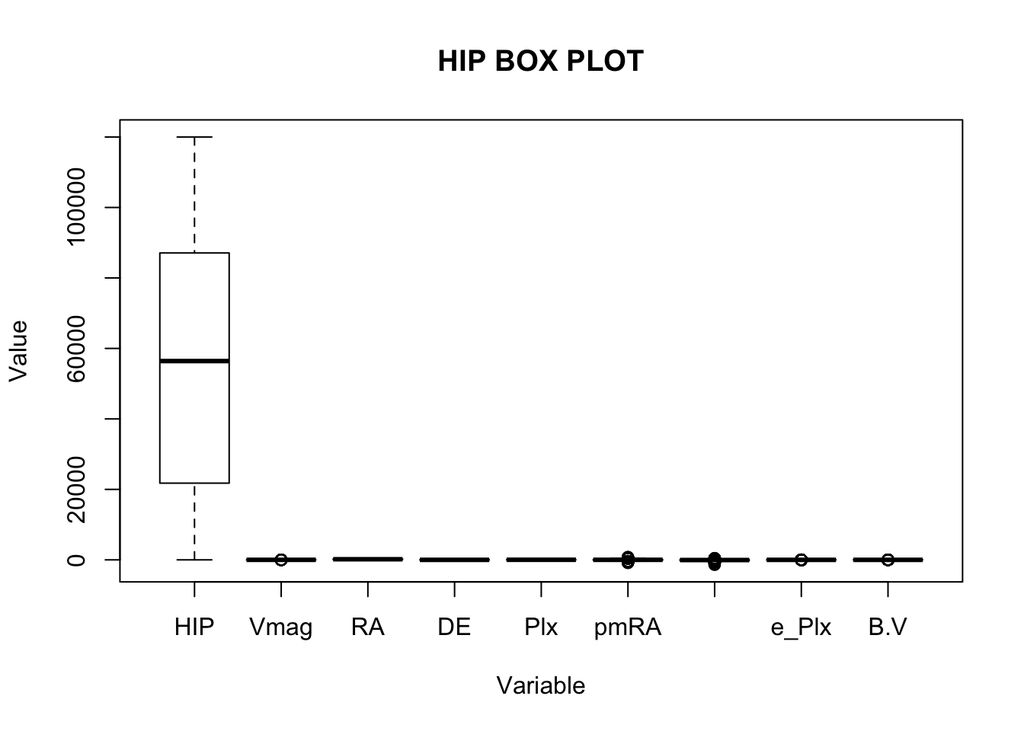

```r
boxplot(hip, main="HIP BOX PLOT", ylab="Value", xlab="Variable")
```

Vemos que el gráfico no es muy revelador esto es porque tenemos variables de rangos muy distintos, podemos normalizarlas para ver algo mejor la dispersion de los datos. De todas formas este gráfico ya nos aportaria información como que la variable HIP está muy por encima de los valores de las demás que se encuentran en rangos similares en función a esta y que tenemos presencia de bastantes outliers en pmRA y pmDE. Vamos a normalizar para ver si el resultado mejora:

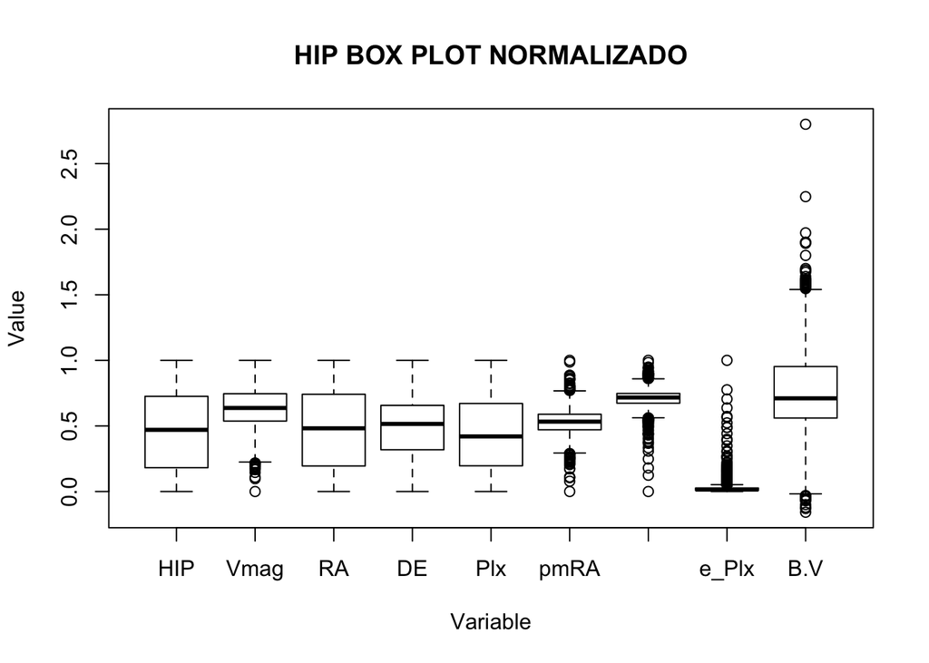

```r
library(scales)
hip_norm<-hip

hip_norm$HIP <- rescale(hip$HIP)
hip_norm$Vmag <- rescale(hip$Vmag)
hip_norm$RA <- rescale(hip$RA)
hip_norm$DE <-rescale(hip$DE)
hip_norm$Plx<-rescale(hip$Plx)
hip_norm$pmRA<-rescale(hip$pmRA)
hip_norm$pmDE<-rescale(hip$pmDE)
hip_norm$e_Plx<-rescale(hip$e_Plx)


boxplot(hip_norm, main="HIP BOX PLOT NORMALIZADO", ylab="Value", xlab="Variable")
```

- Crea un scatterplot que te compare los valores de RA y DE. Representa los puntos con el símbolo ‘.’ Y que estos puntos sean de color rojo si DE excede de 0. Sugerencia ifelse()

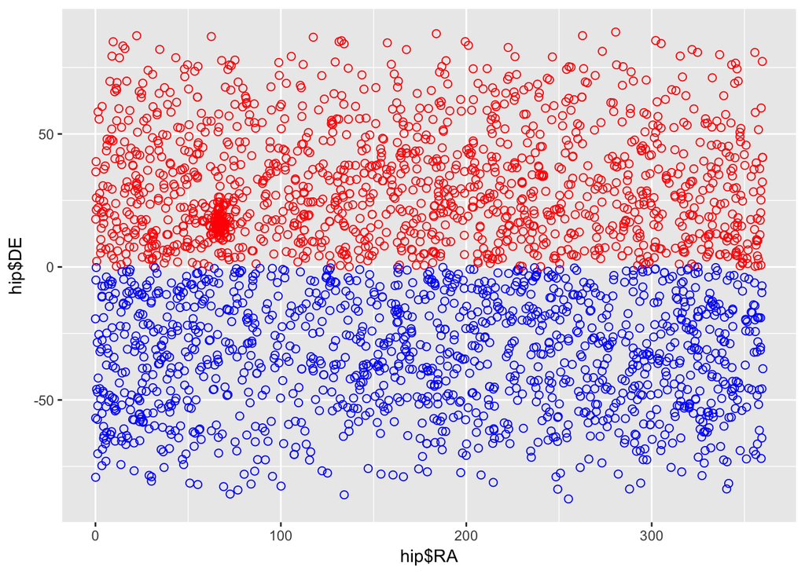

```r
ggplot(hip, aes(x=hip$RA, y=hip$DE))+ geom_point(size=2,color=ifelse(hip$DE>0,"red","blue"),shape=1)
```

- Haz un scatterplot de RA y pmRA. ¿Ves algún patrón?

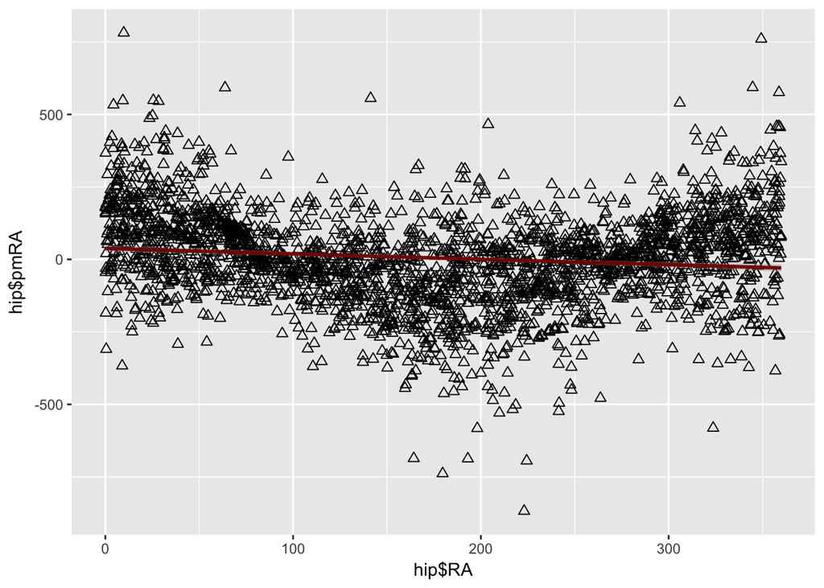

```r
ggplot(hip, aes(x=hip$RA, y=hip$pmRA))+ geom_point(size=2,shape=2)+geom_smooth(method=lm,color="darkred")
```

- En vez de crear los plots por separado para cada par de columnas, hazlos con un solo comando con el scatterplot matrix.

Para esto podemos usar pairs, pero si usamos el comando ggpairs nos ofrecerá mas informacion como correlaciones entre vairables e incluso distribuciones de las mismas.

```r
install.packages("GGAlly")
```

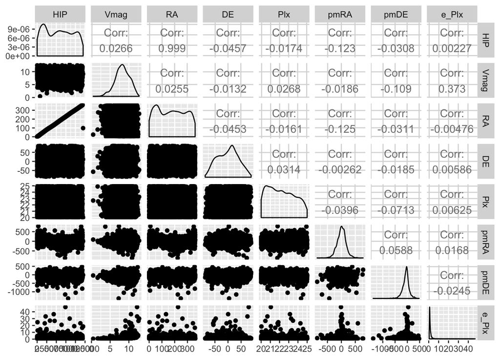

```r
library(GGally)
ggpairs(hip[1:8])
```

- Para poder acceder a las variables por su nombre usa attach(hip).Vamos a seleccionar las estrellas Hyadas del dataset aplicando los siguientes filtros:
1. RA in the range (50,100)
2. DE in the range (0,25)
3. pmRA in the range (90,130)
4. pmDE in the range (-60,-10)
5. e_Plx <5
6. Vmag >4 OR B.V <0.2

Crea un nuevo dataset con la aplicación de estos filtro. El Nuevo dataset se llama hyades.

```r
hip <- hip[complete.cases(hip), ]
hyades<-hip[hip$RA > 50 & hip$RA < 100 &
    hip$DE>0 & hip$DE<25 &
    hip$pmRA>90 & hip$pmRA<130 &
    hip$pmDE> -60 & hip$pmDE< -10 &
    hip$e_Plx < 5 &
    (hip$Vmag>4|hip$B.V<0.2),]

hyades
```

```
##       HIP  Vmag       RA       DE   Plx   pmRA   pmDE e_Plx   B.V
## 533 18735  5.89 60.20286 18.19407 21.99 129.49 -28.27  0.81 0.319
## 537 18946 10.12 60.91235 19.45509 23.07 119.02 -34.19  2.12 1.095
## 541 19148  7.85 61.56690 15.69817 21.41 118.53 -19.59  1.47 0.593
## 543 19207 10.49 61.75479 15.33508 23.57 122.63 -18.96  2.26 1.180
## 545 19261  6.02 61.92461 15.16284 21.27 127.06 -22.75  1.03 0.397
## 547 19316 11.28 62.11082 12.19187 24.90 115.35 -13.05  2.59 1.327
## 553 19504  6.61 62.67620 18.42333 23.22 123.92 -31.41  0.92 0.427
## 555 19781  8.45 63.60661 14.62508 21.91 105.61 -19.86  1.27 0.693
## 557 19793  8.05 63.63433 23.57506 21.69 121.09 -48.34  1.14 0.657
## 559 19808 10.69 63.71610 13.05500 22.67 114.46 -19.28  2.30 1.204
## 562 19877  6.31 63.94256 15.40075 22.51 114.38 -22.07  0.82 0.400
## 565 20019  8.32 64.41197 16.94791 21.40 113.07 -21.39  1.24 0.756
## 566 20056  7.53 64.50737 18.25688 21.84 115.65 -31.23  1.14 0.681
## 567 20082  9.57 64.58000 16.08839 20.01 121.88 -19.72  1.91 0.980
```

[output cut: 74 more lines]

- ¿Que dimensiones tiene el dataset creado? Grafica un scatterplot de Vmag vs B.V

Tiene 88 observaciones con 9 variables cada una.

```r
str(hyades)
```

```
## 'data.frame':    88 obs. of  9 variables:
##  $ HIP  : int  18735 18946 19148 19207 19261 19316 19504 19781 19793 19808 ...
##  $ Vmag : num  5.89 10.12 7.85 10.49 6.02 ...
##  $ RA   : num  60.2 60.9 61.6 61.8 61.9 ...
##  $ DE   : num  18.2 19.5 15.7 15.3 15.2 ...
##  $ Plx  : num  22 23.1 21.4 23.6 21.3 ...
##  $ pmRA : num  129 119 119 123 127 ...
##  $ pmDE : num  -28.3 -34.2 -19.6 -19 -22.8 ...
##  $ e_Plx: num  0.81 2.12 1.47 2.26 1.03 2.59 0.92 1.27 1.14 2.3 ...
##  $ B.V  : num  0.319 1.095 0.593 1.18 0.397 ...
```

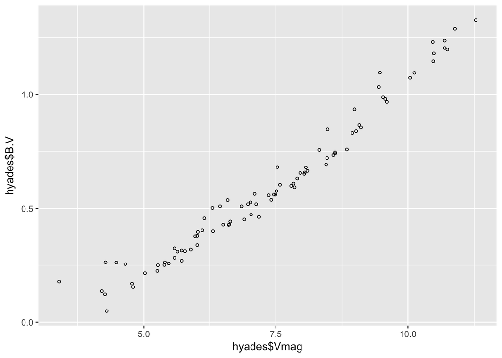

```r
ggplot(hyades, aes(x=hyades$Vmag, y=hyades$B.V))+ geom_point(size=1,shape=1)
```

Analizando el gráfico podemos ver que la relación de las variables es totalmente lineal, lo que podria ayudarnos por ejemplo a poder predecir mediente regresión posibles valores perdidos en una de ambas. Tambien podremos descartar una de ellas en función de otra en nuestros modelos ya que ambas pueden aportar información muy similar al estár tan correlacionadas.

# Ejemplo 2, iris dataset

Vamos a utilizar el ejemplo del dataset iris que está incluido en la distribución de R. Este dataset fue creado por **Douglas Fisher**. Consta de tres clases y tipos de 3 clases de tipos de flores:

1. Setosa_
2. Virginica
3. Versicolor

Cada una de ellas con cuatro atributos:

1. sepal width
2. sepal length
3. petal width
4. petal length
- Inspecciona las primeras filas del dataset y calcula el summary() del mismo con cada atributo del dataset.

```r
iris.data<-iris
head(iris.data)
```

```
##   Sepal.Length Sepal.Width Petal.Length Petal.Width Species
## 1          5.1         3.5          1.4         0.2  setosa
## 2          4.9         3.0          1.4         0.2  setosa
## 3          4.7         3.2          1.3         0.2  setosa
## 4          4.6         3.1          1.5         0.2  setosa
## 5          5.0         3.6          1.4         0.2  setosa
## 6          5.4         3.9          1.7         0.4  setosa
```

```r
summary(iris.data)
```

```
##   Sepal.Length    Sepal.Width     Petal.Length    Petal.Width
##  Min.   :4.300   Min.   :2.000   Min.   :1.000   Min.   :0.100
##  1st Qu.:5.100   1st Qu.:2.800   1st Qu.:1.600   1st Qu.:0.300
##  Median :5.800   Median :3.000   Median :4.350   Median :1.300
##  Mean   :5.843   Mean   :3.057   Mean   :3.758   Mean   :1.199
##  3rd Qu.:6.400   3rd Qu.:3.300   3rd Qu.:5.100   3rd Qu.:1.800
##  Max.   :7.900   Max.   :4.400   Max.   :6.900   Max.   :2.500
##        Species
##  setosa    :50
##  versicolor:50
##  virginica :50
##
##
##
```

```r
str(iris.data)
```

```
## 'data.frame':    150 obs. of  5 variables:
##  $ Sepal.Length: num  5.1 4.9 4.7 4.6 5 5.4 4.6 5 4.4 4.9 ...
##  $ Sepal.Width : num  3.5 3 3.2 3.1 3.6 3.9 3.4 3.4 2.9 3.1 ...
##  $ Petal.Length: num  1.4 1.4 1.3 1.5 1.4 1.7 1.4 1.5 1.4 1.5 ...
##  $ Petal.Width : num  0.2 0.2 0.2 0.2 0.2 0.4 0.3 0.2 0.2 0.1 ...
##  $ Species     : Factor w/ 3 levels "setosa","versicolor",..: 1 1 1 1 1 1 1 1 1 1 ...
```

- Crea un histograma de petal.width , teniendo en cuenta que el número de bins es variable fija este a 9. Añádele color y nombres al eje x “Petal Width”y al gráfico dale el nombre de “Histogram of Petal Width”.

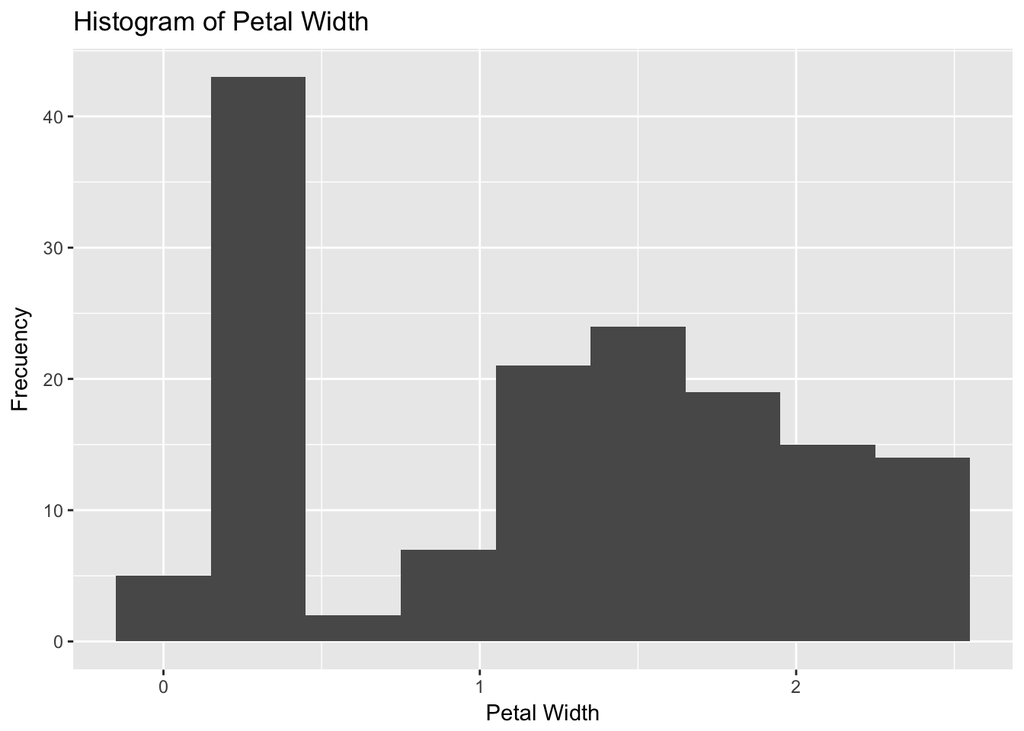

```r
library(ggplot2)
ggplot(data=iris.data, aes(iris.data$Petal.Width)) + geom_histogram(binwidth = 0.3) +labs(title="Histogram of Petal Width",x ="Petal Width", y = "Frecuency")
```

- Crea un histograma para cada variable.

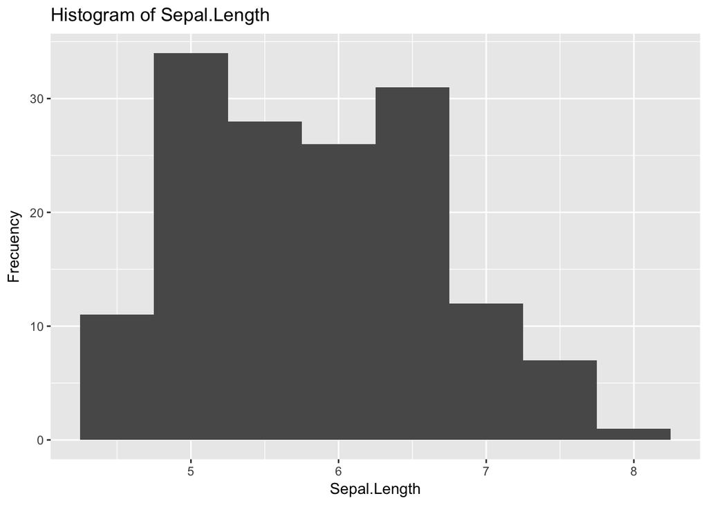

```r
ggplot(data=iris.data, aes(iris.data$Sepal.Length)) + geom_histogram(binwidth = 0.5) +labs(title="Histogram of Sepal.Length",x ="Sepal.Length", y = "Frecuency")
```

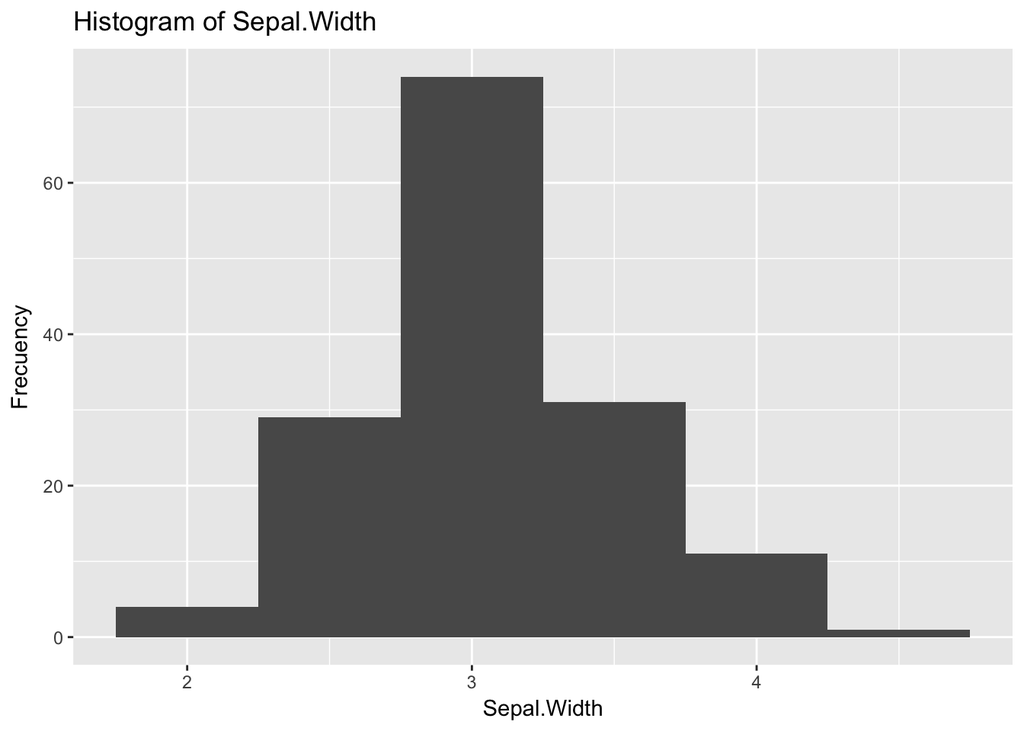

```r
ggplot(data=iris.data, aes(iris.data$Sepal.Width)) + geom_histogram(binwidth = 0.5) +labs(title="Histogram of Sepal.Width",x ="Sepal.Width", y = "Frecuency")
```

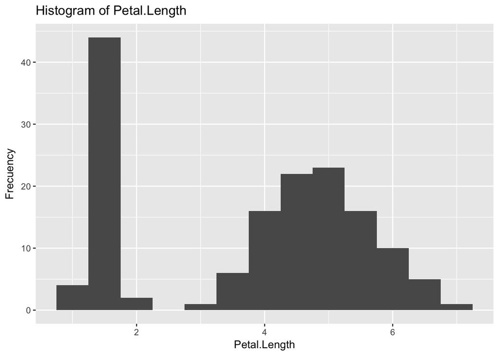

```r
ggplot(data=iris.data, aes(iris.data$Petal.Length)) + geom_histogram(binwidth = 0.5) +labs(title="Histogram of Petal.Length",x ="Petal.Length", y = "Frecuency")
```

- Crea los cuartiles del dataset

```r
summary(iris.data, na.rm=T)
```

```
##   Sepal.Length    Sepal.Width     Petal.Length    Petal.Width
##  Min.   :4.300   Min.   :2.000   Min.   :1.000   Min.   :0.100
##  1st Qu.:5.100   1st Qu.:2.800   1st Qu.:1.600   1st Qu.:0.300
##  Median :5.800   Median :3.000   Median :4.350   Median :1.300
##  Mean   :5.843   Mean   :3.057   Mean   :3.758   Mean   :1.199
##  3rd Qu.:6.400   3rd Qu.:3.300   3rd Qu.:5.100   3rd Qu.:1.800
##  Max.   :7.900   Max.   :4.400   Max.   :6.900   Max.   :2.500
##        Species
##  setosa    :50
##  versicolor:50
##  virginica :50
##
##
##
```

- Representa en un boxplot la variable de ancho de hoja dependiendo del tipo de hoja que tengan.

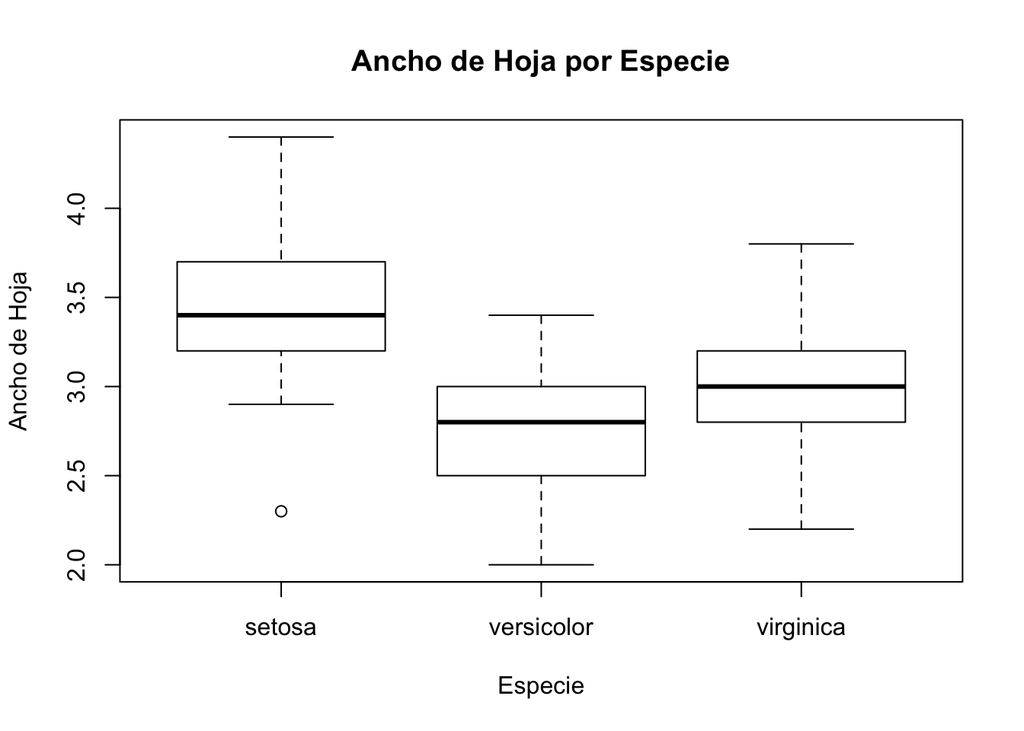

```r
boxplot(iris.data$Sepal.Width~iris.data$Species, main="Ancho de Hoja por Especie", ylab="Ancho de Hoja", xlab="Especie")
```

Este gráfico no podemos ver una tendencia clara, más haya de que encontramos los cuartiles bien distribuidos y salvo un caso la existencia de outliers es nula.

- Crea los boxplot de la longitud del pétalo en función de la especie de Iris.

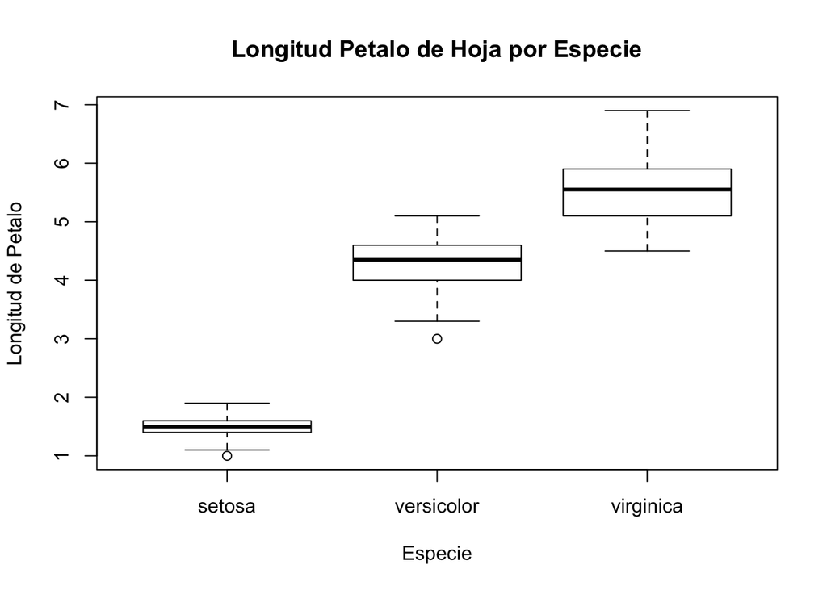

```r
boxplot(iris.data$Petal.Length~iris.data$Species, main="Longitud Petalo de Hoja por Especie", ylab="Longitud de Petalo", xlab="Especie")
```

- Compara con scatter plots las variables entre sí.

Vamos a volver a usar ggpairs, que nos ofrece mucha más información.

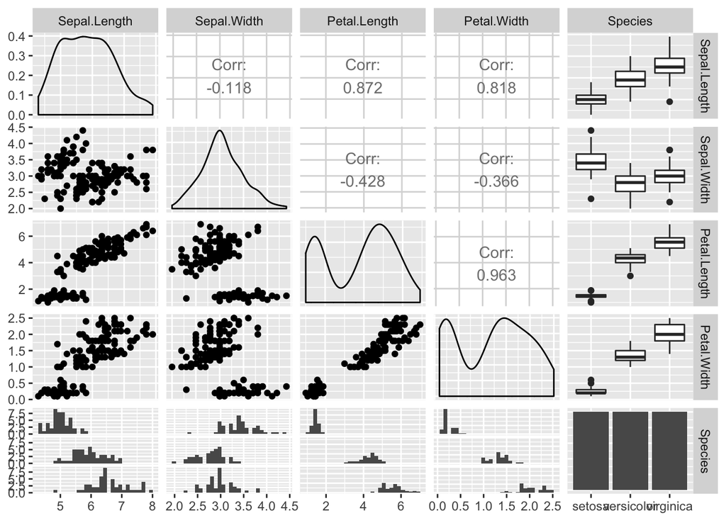

```r
ggpairs(iris.data)
```